# Multi-Sample Multi-condition Cell-Cell Communication Analysis via NicheNet: HNSCC application; All-vs-All

## Visualization of ligand-activity, ligand-target links, and target gene expression

In another type of plot, we can visualize the ligand activities for a group-receiver combination, and show the predicted ligand-target links, and also the expression of the predicted target genes across samples.

First: show this for a selection of ligands with high ligand activities:

```r
# group_oi = "High"
# receiver_oi = "Malignant"
# prioritized_tbl_oi = multinichenet_output$prioritization_tables$group_prioritization_tbl %>%
#   filter(fraction_ligand_group > fraction_cutoff & fraction_receptor_group > fraction_cutoff) %>%
#   distinct(id, sender, receiver, ligand, receptor, group, prioritization_score, ligand_receptor_lfc_avg, fraction_expressing_ligand_receptor, activity_scaled) %>%
#   filter(fraction_expressing_ligand_receptor > 0) %>%
#   filter(group == group_oi & receiver == receiver_oi) %>%
#   group_by(group) %>% top_n(50, prioritization_score) %>% top_n(25, activity_scaled) %>% arrange(-activity_scaled)
```

```r
# combined_plot = make_ligand_activity_target_plot(group_oi, receiver_oi, prioritized_tbl_oi, multinichenet_output$prioritization_tables, multinichenet_output$ligand_activities_targets_DEgenes, contrast_tbl, multinichenet_output$grouping_tbl, multinichenet_output$celltype_info, ligand_target_matrix, plot_legend = FALSE)
# combined_plot
```

Now: show this for a selection of ligands with high general prioritization scores, not necessarily high ligand activities.

```r
# group_oi = "High"
# receiver_oi = "Malignant"
# prioritized_tbl_oi = multinichenet_output$prioritization_tables$group_prioritization_tbl %>%
#   filter(fraction_ligand_group > fraction_cutoff & fraction_receptor_group > fraction_cutoff) %>%
#   distinct(id, sender, receiver, ligand, receptor, group, prioritization_score, ligand_receptor_lfc_avg, fraction_expressing_ligand_receptor, activity_scaled) %>%
#   filter(fraction_expressing_ligand_receptor > 0) %>%
#   filter(group == group_oi & receiver == receiver_oi) %>%
#   group_by(group) %>% top_n(100, prioritization_score) %>% arrange(-activity_scaled)
prioritized_tbl_oi_high30 = get_top_n_lr_pairs(prioritization_tables, 30, groups_oi = group_oi, receivers_oi = receiver_oi)
```

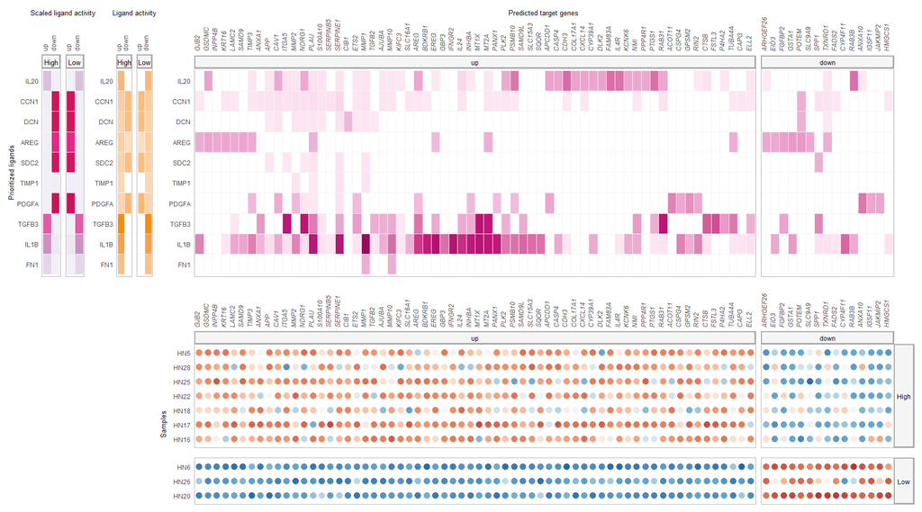

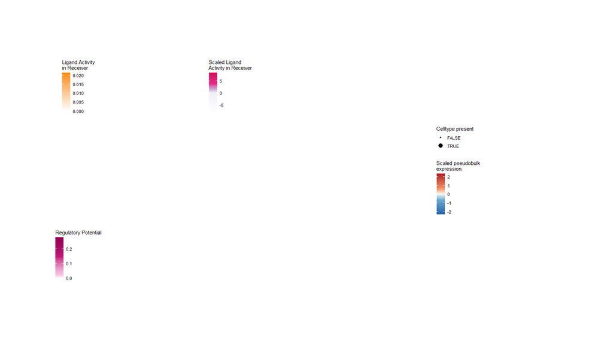

```r
combined_plot = make_ligand_activity_target_plot(group_oi, receiver_oi, prioritized_tbl_oi_high30, multinichenet_output$prioritization_tables, multinichenet_output$ligand_activities_targets_DEgenes, contrast_tbl, multinichenet_output$grouping_tbl, multinichenet_output$celltype_info, ligand_target_matrix, plot_legend = FALSE)
combined_plot
## $combined_plot
```

Of course you can look at other receivers as well:

```r
group_oi = "High"
receiver_oi = "myofibroblast"
# prioritized_tbl_oi = multinichenet_output$prioritization_tables$group_prioritization_tbl %>%
#   filter(fraction_ligand_group > fraction_cutoff & fraction_receptor_group > fraction_cutoff) %>%
#   distinct(id, sender, receiver, ligand, receptor, group, prioritization_score, ligand_receptor_lfc_avg, fraction_expressing_ligand_receptor, activity_scaled) %>%
#   filter(fraction_expressing_ligand_receptor > 0) %>%
#   filter(group == group_oi & receiver == receiver_oi) %>%
#   group_by(group) %>% top_n(25, prioritization_score) %>% arrange(-activity_scaled)
prioritized_tbl_oi_high30 = get_top_n_lr_pairs(prioritization_tables, 30, groups_oi = group_oi, receivers_oi = receiver_oi)
```

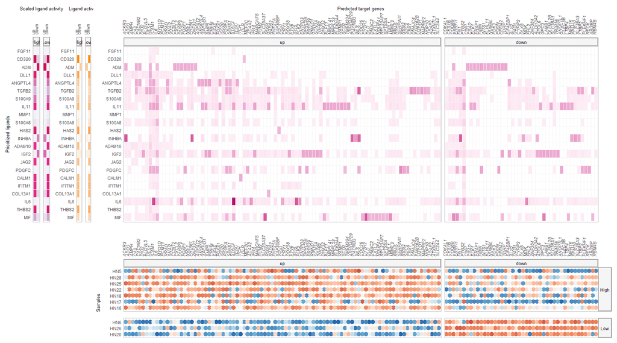

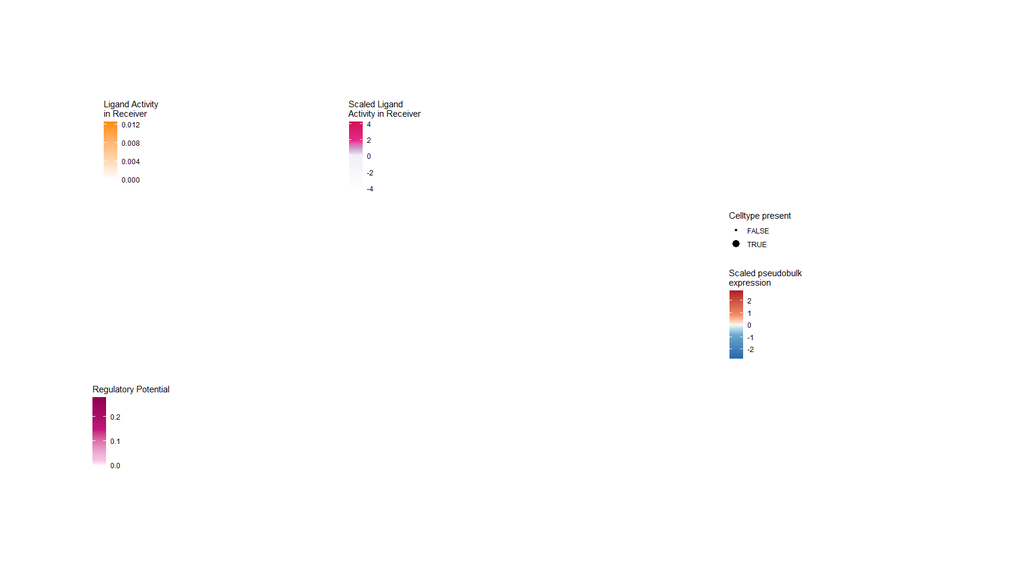

```r
combined_plot = make_ligand_activity_target_plot(group_oi, receiver_oi, prioritized_tbl_oi_high30, multinichenet_output$prioritization_tables, multinichenet_output$ligand_activities_targets_DEgenes, contrast_tbl, multinichenet_output$grouping_tbl, multinichenet_output$celltype_info, ligand_target_matrix, plot_legend = FALSE)
combined_plot
## $combined_plot
```

## Show ligand activities for each receiver-group combination

In the next type of plot, we plot all the ligand activities (Both scaled and absolute activities) of each receiver-group combination. This can give us some insights in active signaling pathways across groups. Note that we can thus show top ligands based on ligand activity - agnostic of expression in sender.

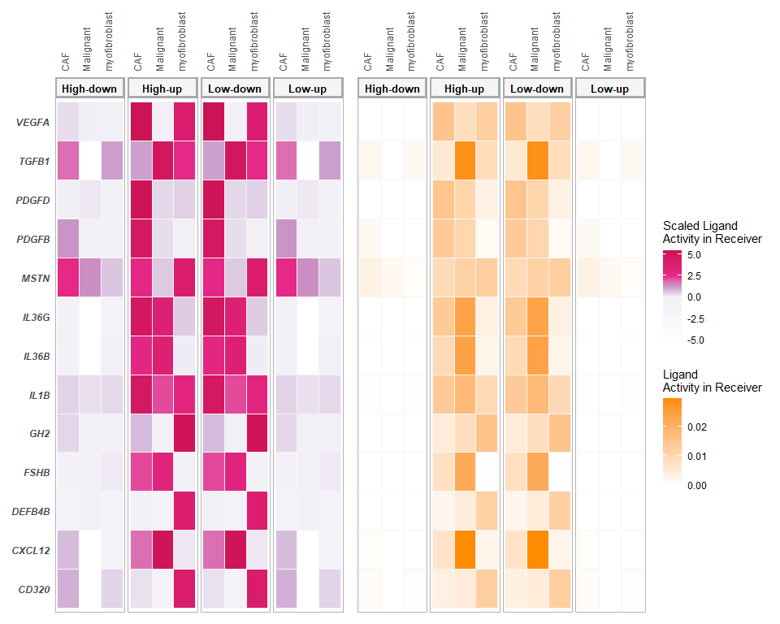

```r
ligands_oi = multinichenet_output$prioritization_tables$ligand_activities_target_de_tbl %>% inner_join(contrast_tbl) %>%
  group_by(group, receiver) %>% distinct(ligand, receiver, group, activity) %>%
  top_n(5, activity) %>% pull(ligand) %>% unique()

plot_oi = make_ligand_activity_plots(multinichenet_output$prioritization_tables, ligands_oi, contrast_tbl, widths = NULL)
plot_oi
```

Or we can do this plot for ligands, while considering the general priorization score (which considers expression information etc)

Show top ligands based on prioritization scores

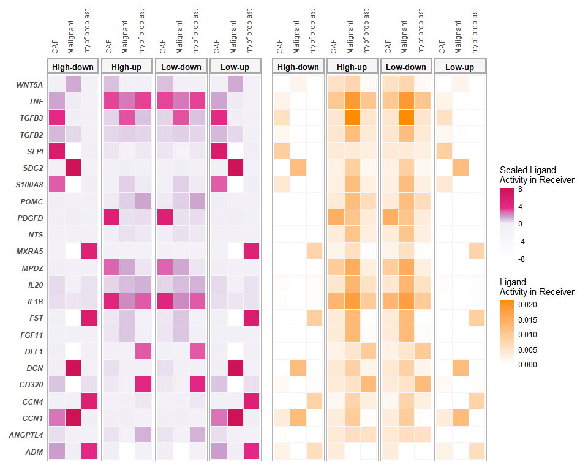

```r
ligands_oi = multinichenet_output$prioritization_tables$group_prioritization_tbl %>%
  group_by(group, receiver) %>% distinct(ligand, receiver, group, prioritization_score) %>%
  top_n(5, prioritization_score) %>% pull(ligand) %>% unique()

plot_oi = make_ligand_activity_plots(multinichenet_output$prioritization_tables, ligands_oi, contrast_tbl, widths = NULL)
plot_oi
```

## Zoom in on specific ligand-receptor interactions: show their expression in the single-cell data!

Single-cell-based Feature, and Violin plots of ligand-receptor interaction of interest: `make_ligand_receptor_feature_plot` and `make_ligand_receptor_violin_plot`

It is often useful to zoom in on specific ligand-receptor interactions of interest by looking in more detail to their expression at the single cell level

Check the highest scoring links based on the general prioritization score. Here we will pick one of those to visualize.

```r
prioritized_tbl_oi_high30
## # A tibble: 30 x 8
## # Groups:   group [1]
##    group sender        receiver      ligand  receptor id                                        prioritization_score prioritization_rank
##    <chr> <chr>         <chr>         <chr>   <chr>    <chr>                                                    <dbl>               <dbl>
##  1 High  Malignant     myofibroblast FGF11   SCN3A    FGF11_SCN3A_Malignant_myofibroblast                       2.07                   1
##  2 High  Malignant     myofibroblast CD320   LRPAP1   CD320_LRPAP1_Malignant_myofibroblast                      2.06                   2
##  3 High  CAF           myofibroblast ADM     RAMP1    ADM_RAMP1_CAF_myofibroblast                               2.03                   3
##  4 High  Malignant     myofibroblast DLL1    NOTCH3   DLL1_NOTCH3_Malignant_myofibroblast                       2.03                   4
##  5 High  myofibroblast myofibroblast ANGPTL4 SDC2     ANGPTL4_SDC2_myofibroblast_myofibroblast                  2.03                   5
##  6 High  myofibroblast myofibroblast ANGPTL4 ITGB1    ANGPTL4_ITGB1_myofibroblast_myofibroblast                 2.00                   6
##  7 High  myofibroblast myofibroblast ANGPTL4 ITGAV    ANGPTL4_ITGAV_myofibroblast_myofibroblast                 2.00                   7
##  8 High  myofibroblast myofibroblast TGFB2   TGFBR3   TGFB2_TGFBR3_myofibroblast_myofibroblast                  2.00                   8
##  9 High  Malignant     myofibroblast S100A9  CD36     S100A9_CD36_Malignant_myofibroblast                       1.99                   9
## 10 High  CAF           myofibroblast IL11    IL6R     IL11_IL6R_CAF_myofibroblast                               1.99                  10
## # ... with 20 more rows
```

```r
ligand_oi = "DLL1"
receptor_oi = "NOTCH3"
group_oi = "High"
sender_oi = "Malignant"
receiver_oi = "myofibroblast"
```

Nebulosa and Feature plot of the ligand in the sender cell type and the receptor in the receiver cell type (split per condition)

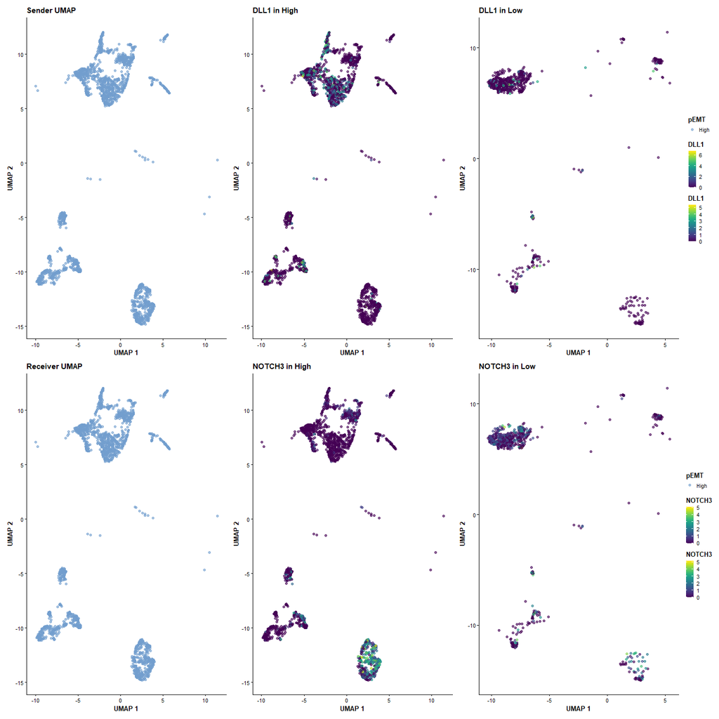

```r
p_feature = make_ligand_receptor_feature_plot(sce_sender = sce, sce_receiver = sce, ligand_oi = ligand_oi, receptor_oi = receptor_oi, group_oi = group_oi, group_id = group_id, celltype_id_sender = celltype_id, celltype_id_receiver = celltype_id, senders_oi = c("Malignant","myofibroblast","CAF"), receivers_oi = c("Malignant","myofibroblast","CAF"))

p_feature
```

Pooled single-cell and sample-specific single-cell violin plots of ligand and receptor expression in respectively sender and receiver.

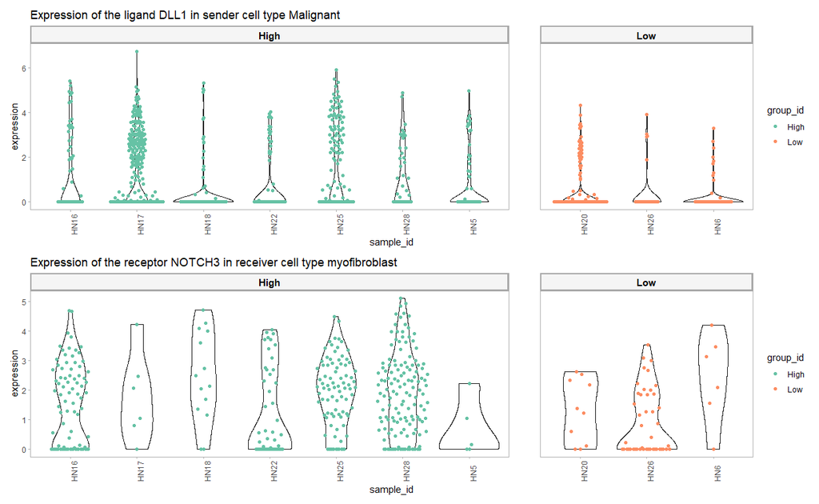

```r
p_violin = make_ligand_receptor_violin_plot(sce_sender = sce, sce_receiver = sce, ligand_oi = ligand_oi, receptor_oi = receptor_oi, group_oi = group_oi, group_id = group_id, sender_oi = sender_oi, receiver_oi = receiver_oi, sample_id = sample_id, celltype_id_sender = celltype_id, celltype_id_receiver = celltype_id)
p_violin
```

## Zoom in on specific ligand-target interactions: show their expression in the single-cell data!

Make target gene violin and feature plots: `make_target_violin_plot` and `make_target_feature_plot`

```r
receiver_oi = "Malignant"
group_oi = "High"

multinichenet_output$ligand_activities_targets_DEgenes$de_genes_df %>% inner_join(contrast_tbl) %>% filter(p_val <= 0.05) %>% filter(group == group_oi) %>% filter(receiver == receiver_oi) %>% arrange(p_val) %>% top_n(100, logFC)
## # A tibble: 100 x 7
##    gene   receiver  logFC   p_val p_adj contrast group
##    <chr>  <chr>     <dbl>   <dbl> <dbl> <chr>    <chr>
##  1 RAB31  Malignant  3    0.00200 0.999 High-Low High
##  2 AHNAK2 Malignant  2.3  0.00260 0.999 High-Low High
##  3 GSDMC  Malignant  3.19 0.00306 0.999 High-Low High
##  4 ITGB6  Malignant  3.75 0.00433 0.999 High-Low High
##  5 ITGA3  Malignant  1.85 0.00497 0.999 High-Low High
##  6 CA2    Malignant  5.8  0.00562 0.999 High-Low High
##  7 GALNT6 Malignant  1.76 0.00597 0.999 High-Low High
##  8 KCNK6  Malignant  2.57 0.00681 0.999 High-Low High
##  9 PLEK2  Malignant  1.93 0.00687 0.999 High-Low High
## 10 GJB6   Malignant  3.33 0.00819 0.999 High-Low High
## # ... with 90 more rows
```

RAB31: interesting gene

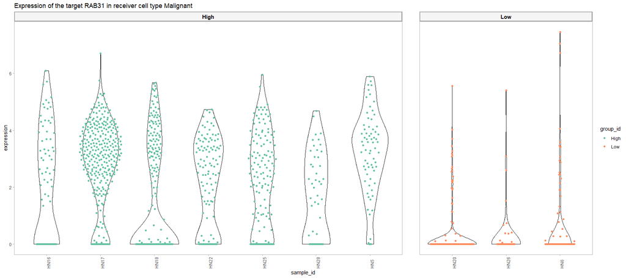

```r
target_oi = "RAB31"

make_target_violin_plot(sce_receiver = sce, target_oi = target_oi, receiver_oi = receiver_oi, group_oi = group_oi, group_id = group_id, sample_id, celltype_id_receiver = celltype_id)
```

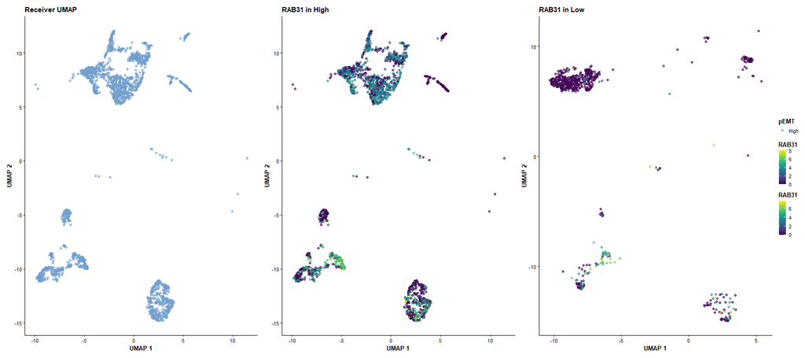

```r
make_target_feature_plot(sce_receiver = sce, target_oi = target_oi, group_oi = group_oi, group_id = group_id, celltype_id_receiver = celltype_id, receivers_oi = c("Malignant","myofibroblast","CAF"))
```

## Make Dotplot for all DE genes/targets

Note: DE here determined based on the parameters used for the MultiNicheNet analysis (cf above): this means that DE genes are here not based on the p-value corrected for multiple testing!

```r
receiver_oi = "Malignant"
group_oi = "High"

targets_oi = multinichenet_output$ligand_activities_targets_DEgenes$de_genes_df %>% inner_join(contrast_tbl) %>% filter(group == group_oi) %>% arrange(p_val) %>% filter(receiver == receiver_oi) %>% pull(gene) %>% unique()
```

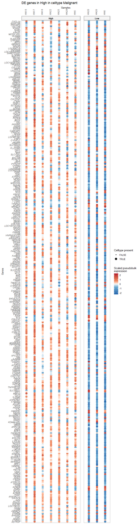

```r
p_target = make_DEgene_dotplot_pseudobulk(targets_oi, celltype_info = multinichenet_output$celltype_info, prioritization_tables,  receiver_oi, multinichenet_output$grouping_tbl)
p_target$pseudobulk_plot + ggtitle(paste0("DE genes in ",group_oi, " in celltype ",receiver_oi))
```

## Visualization of expression-correlated target genes of ligand-receptor pairs

To filter we can use one of these two options: `lr_target_prior_cor_filtered` (recommended and based on ligand-target prior knowledge: the target should be a top target of the ligand, and the ligand should be a top ligand for the target) or `lr_target_prior_cor_filtered_original` (based on the same ligand-target df returned by default in classic NicheNet: focuses on top targets of a ligand only, and not necessarily the reverse)

```r
group_oi = "High"
receiver_oi = "Malignant"
lr_target_prior_cor_filtered = multinichenet_output$lr_target_prior_cor %>% inner_join(ligand_activities_targets_DEgenes$ligand_activities %>% distinct(ligand, target, direction_regulation, contrast)) %>% inner_join(contrast_tbl) %>% filter(group == group_oi, receiver == receiver_oi)
# lr_target_prior_cor_filtered = multinichenet_output$lr_target_prior_cor %>% filter( (rank_of_target < top_n_target | rank_of_ligand < 10) & (pearson > 0.75 | spearman > 0.75))
lr_target_prior_cor_filtered_up = lr_target_prior_cor_filtered %>% filter(direction_regulation == "up") %>% filter( (rank_of_target < top_n_target) & (pearson > 0.75 | spearman > 0.75))
lr_target_prior_cor_filtered_down = lr_target_prior_cor_filtered %>% filter(direction_regulation == "down") %>% filter( (rank_of_target < top_n_target) & (pearson < -0.75 | spearman < -0.75))
lr_target_prior_cor_filtered = bind_rows(lr_target_prior_cor_filtered_up, lr_target_prior_cor_filtered_down)
```

```r
# prioritized_tbl_oi = multinichenet_output$prioritization_tables$group_prioritization_tbl %>% distinct(id, ligand, receptor, sender, receiver, lr_interaction, group, ligand_receptor_lfc_avg, activity_scaled, fraction_expressing_ligand_receptor,  prioritization_score) %>% filter(fraction_expressing_ligand_receptor > 0 & ligand_receptor_lfc_avg > 0) %>% filter(group == group_oi & receiver == receiver_oi) %>% top_n(100, prioritization_score)
# # prioritized_tbl_oi = prioritized_tbl_oi %>% filter(id %in% lr_target_prior_cor_filtered$id)
prioritized_tbl_oi = get_top_n_lr_pairs(prioritization_tables, 100, groups_oi = group_oi, receivers_oi = receiver_oi)
# prioritized_tbl_oi = prioritized_tbl_oi %>% group_by(ligand, sender, group) %>% top_n(3, prioritization_score) # keep max three receptors per ligand - for visualization purposes
```

First: show the LR–>Target heatmap of prior knowledge supported and correlated links (shows both measure of correlation and measure of prior knowledge)

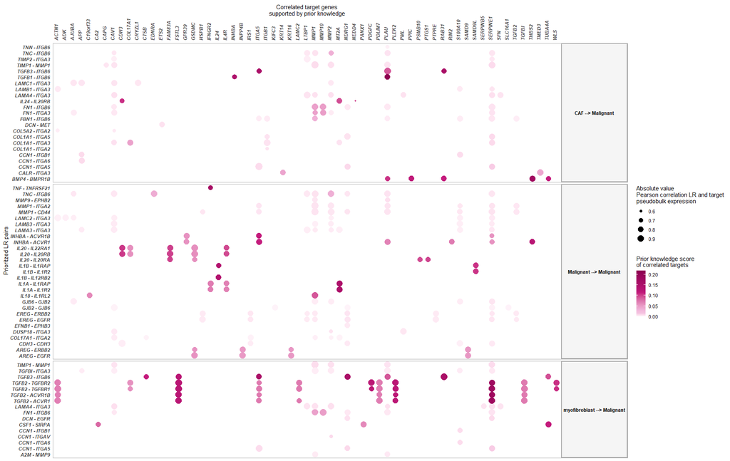

```r
lr_target_prior_cor_heatmap = make_lr_target_prior_cor_heatmap(lr_target_prior_cor_filtered_up %>% filter(receiver == receiver_oi & id %in% prioritized_tbl_oi$id), add_grid = FALSE)
lr_target_prior_cor_heatmap
```

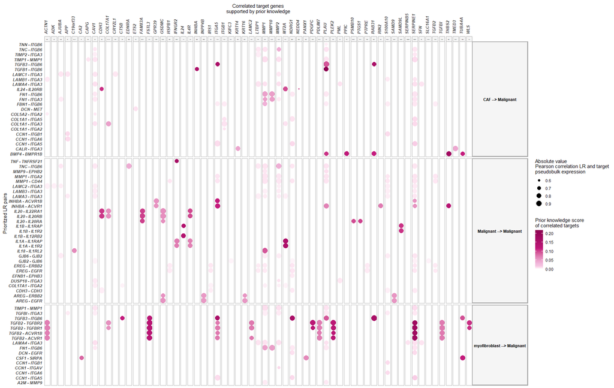

```r
lr_target_prior_cor_heatmap = make_lr_target_prior_cor_heatmap(lr_target_prior_cor_filtered_up %>% filter(receiver == receiver_oi & id %in% prioritized_tbl_oi$id), add_grid = TRUE)
lr_target_prior_cor_heatmap
```

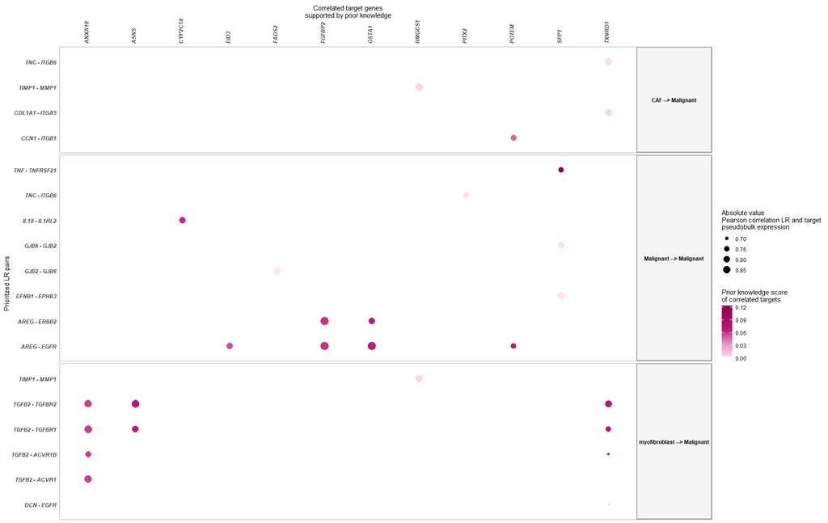

```r
lr_target_prior_cor_heatmap = make_lr_target_prior_cor_heatmap(lr_target_prior_cor_filtered_down %>% filter(receiver == receiver_oi & id %in% prioritized_tbl_oi$id), add_grid = FALSE)
lr_target_prior_cor_heatmap
```

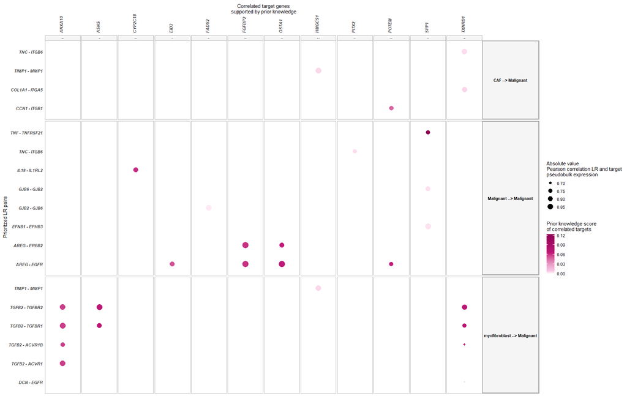

```r
lr_target_prior_cor_heatmap = make_lr_target_prior_cor_heatmap(lr_target_prior_cor_filtered_down %>% filter(receiver == receiver_oi & id %in% prioritized_tbl_oi$id), add_grid = TRUE)
lr_target_prior_cor_heatmap
```

Now visualize these links together with the LR and target expression, to visualize the expression correlation

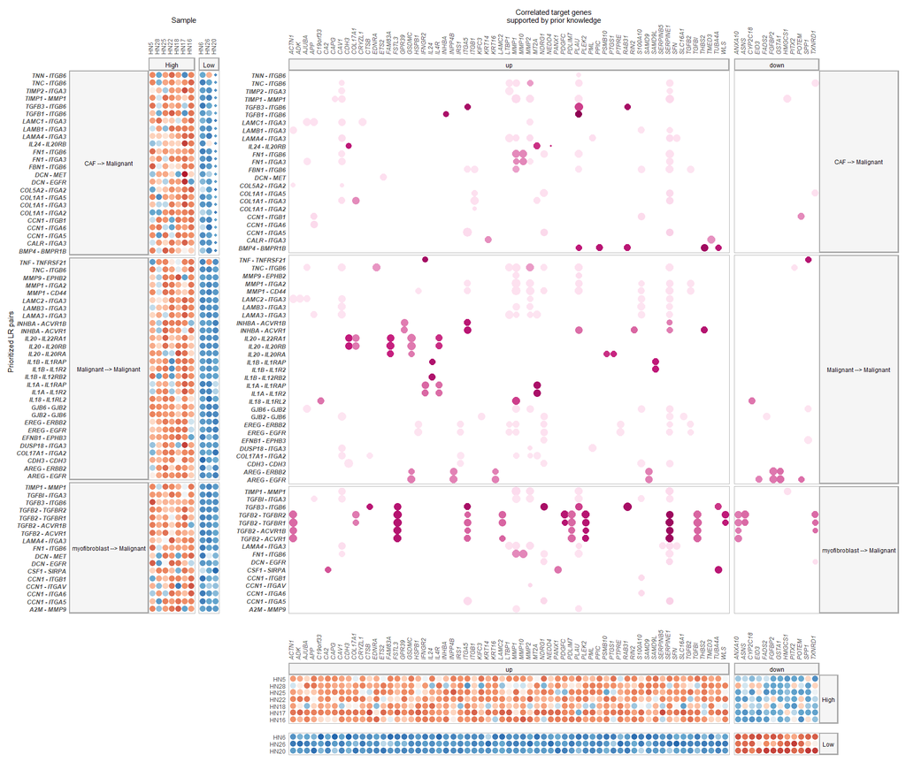

```r
lr_target_correlation_plot = make_lr_target_correlation_plot(multinichenet_output$prioritization_tables, prioritized_tbl_oi,  lr_target_prior_cor_filtered , multinichenet_output$grouping_tbl, multinichenet_output$celltype_info, receiver_oi,plot_legend = FALSE)
lr_target_correlation_plot$combined_plot
```

You can also visualize the expression correlation in the following way for a selected LR pair and their targets:

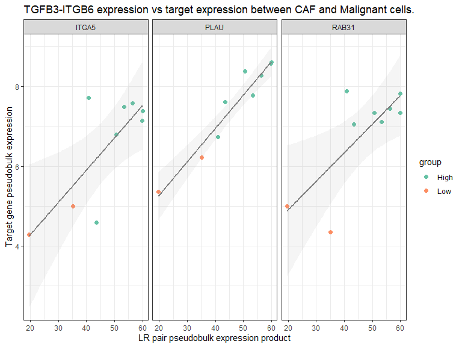

```r
ligand_oi = "TGFB3"
receptor_oi = "ITGB6"
sender_oi = "CAF"
receiver_oi = "Malignant"
lr_target_scatter_plot = make_lr_target_scatter_plot(multinichenet_output$prioritization_tables, ligand_oi, receptor_oi, sender_oi, receiver_oi, multinichenet_output$celltype_info, multinichenet_output$grouping_tbl, lr_target_prior_cor_filtered)
lr_target_scatter_plot
```

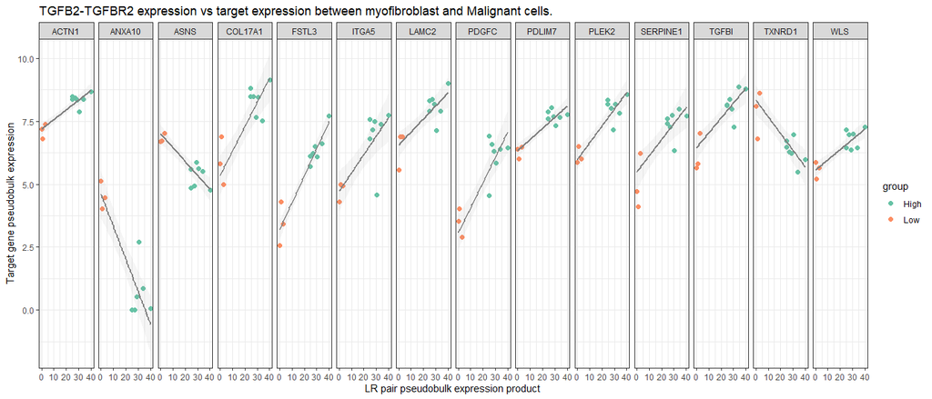

```r
ligand_oi = "TGFB2"
receptor_oi = "TGFBR2"
sender_oi = "myofibroblast"
receiver_oi = "Malignant"
lr_target_scatter_plot = make_lr_target_scatter_plot(multinichenet_output$prioritization_tables, ligand_oi, receptor_oi, sender_oi, receiver_oi, multinichenet_output$celltype_info, multinichenet_output$grouping_tbl, lr_target_prior_cor_filtered)
lr_target_scatter_plot
```

For these targets, you can also visualize the ‘prior knowledge’ ligand-receptor-to-target signaling paths. This is done similarly to the workflow described in https://github.com/saeyslab/nichenetr/blob/master/vignettes/ligand_target_signaling_path.md

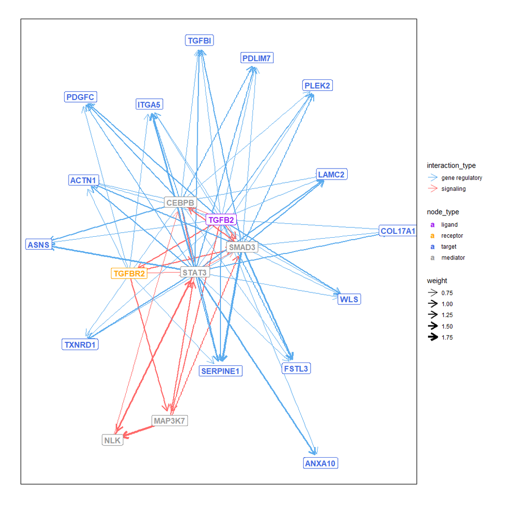

```r
targets_all = lr_target_prior_cor_filtered %>% filter(ligand == ligand_oi & receiver == receiver_oi & sender == sender_oi & receptor == receptor_oi)  %>% pull(target) %>% unique()

active_signaling_network = nichenetr::get_ligand_signaling_path_with_receptor(ligand_tf_matrix = ligand_tf_matrix, ligands_all = ligand_oi, receptors_all = receptor_oi, targets_all = targets_all, weighted_networks = weighted_networks, top_n_regulators = 2)
data_source_network = nichenetr::infer_supporting_datasources(signaling_graph_list = active_signaling_network,lr_network = lr_network, sig_network = sig_network, gr_network = gr_network)

active_signaling_network_min_max = active_signaling_network
active_signaling_network_min_max$sig = active_signaling_network_min_max$sig %>% mutate(weight = ((weight-min(weight))/(max(weight)-min(weight))) + 0.75)
active_signaling_network_min_max$gr = active_signaling_network_min_max$gr %>% mutate(weight = ((weight-min(weight))/(max(weight)-min(weight))) + 0.75)
colors = c("ligand" = "purple", "receptor" = "orange", "target" = "royalblue", "mediator" = "grey60")
ggraph_signaling_path = suppressWarnings(make_ggraph_signaling_path(active_signaling_network_min_max, colors, ligand_oi, receptor_oi, targets_all))
ggraph_signaling_path$plot
```

```r
data_source_network %>% head()
## # A tibble: 6 x 7
##   from  to    source             database       layer      ligand receptor
##   <chr> <chr> <chr>              <chr>          <chr>      <chr>  <chr>
## 1 CEBPB ACTN1 harmonizome_ENCODE harmonizome_gr regulatory <NA>   <NA>
## 2 CEBPB ASNS  harmonizome_ENCODE harmonizome_gr regulatory <NA>   <NA>
## 3 CEBPB ASNS  trrust             trrust         regulatory <NA>   <NA>
## 4 CEBPB ASNS  HTRIDB             HTRIDB         regulatory <NA>   <NA>
## 5 CEBPB ASNS  omnipath_ABC       omnipath       regulatory <NA>   <NA>
## 6 CEBPB FSTL3 harmonizome_ENCODE harmonizome_gr regulatory <NA>   <NA>
```

As last plot, we can generate a ‘systems’ view of the intercellular feedback processes than can be occuring between the different cell populations involved. In this plot, we will draw links between ligands of sender cell types their ligand/receptor-annotated target genes in receiver cell types.

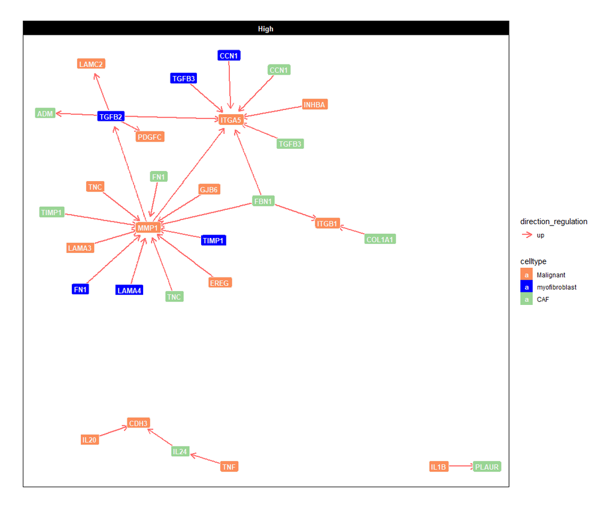

```r
group_oi = "High"

prioritized_tbl_oi = get_top_n_lr_pairs(prioritization_tables, 100, groups_oi = group_oi)

lr_target_prior_cor_filtered = multinichenet_output$lr_target_prior_cor %>% inner_join(ligand_activities_targets_DEgenes$ligand_activities %>% distinct(ligand, target, direction_regulation, contrast)) %>% inner_join(contrast_tbl) %>% filter(group == group_oi)
lr_target_prior_cor_filtered_up = lr_target_prior_cor_filtered %>% filter(direction_regulation == "up") %>% filter( (rank_of_target < top_n_target) & (pearson > 0.75 | spearman > 0.75))
lr_target_prior_cor_filtered_down = lr_target_prior_cor_filtered %>% filter(direction_regulation == "down") %>% filter( (rank_of_target < top_n_target) & (pearson < -0.75 | spearman < -0.75))
lr_target_prior_cor_filtered = bind_rows(lr_target_prior_cor_filtered_up, lr_target_prior_cor_filtered_down)

colors_sender["myofibroblast"] = "blue"
graph_plot = make_ggraph_ligand_target_links(lr_target_prior_cor_filtered = lr_target_prior_cor_filtered, prioritized_tbl_oi = prioritized_tbl_oi, colors = colors_sender)
graph_plot$plot
```

Make a double prioritization table: do this for every condition

```r
prioritized_tbl_oi = get_top_n_lr_pairs(prioritization_tables, 150, rank_per_group = FALSE)

lr_target_prior_cor_filtered = prioritization_tables$group_prioritization_tbl$group %>% unique() %>% lapply(function(group_oi){
  lr_target_prior_cor_filtered = multinichenet_output$lr_target_prior_cor %>% inner_join(ligand_activities_targets_DEgenes$ligand_activities %>% distinct(ligand, target, direction_regulation, contrast)) %>% inner_join(contrast_tbl) %>% filter(group == group_oi)
  lr_target_prior_cor_filtered_up = lr_target_prior_cor_filtered %>% filter(direction_regulation == "up") %>% filter( (rank_of_target < top_n_target) & (pearson > 0.75 | spearman > 0.75))
  lr_target_prior_cor_filtered_down = lr_target_prior_cor_filtered %>% filter(direction_regulation == "down") %>% filter( (rank_of_target < top_n_target) & (pearson < -0.75 | spearman < -0.75))
  lr_target_prior_cor_filtered = bind_rows(lr_target_prior_cor_filtered_up, lr_target_prior_cor_filtered_down)
}) %>% bind_rows()
```

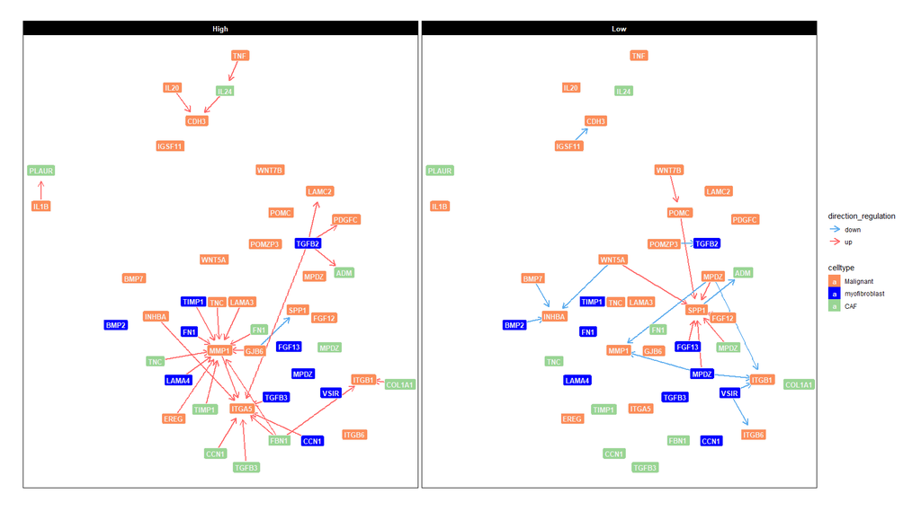

```r
graph_plot = make_ggraph_ligand_target_links(lr_target_prior_cor_filtered = lr_target_prior_cor_filtered, prioritized_tbl_oi = prioritized_tbl_oi, colors = colors_sender)
graph_plot$plot
```

```r
graph_plot$source_df_lt %>% head()
## # A tibble: 6 x 6
##   sender              receiver        direction_regulation group type          weight
##   <chr>               <chr>           <fct>                <chr> <chr>          <dbl>
## 1 Malignant_TNF       CAF_IL24        up                   High  Ligand-Target      1
## 2 myofibroblast_TGFB2 CAF_ADM         up                   High  Ligand-Target      1
## 3 myofibroblast_TGFB2 Malignant_LAMC2 up                   High  Ligand-Target      1
## 4 myofibroblast_TGFB2 Malignant_PDGFC up                   High  Ligand-Target      1
## 5 Malignant_GJB6      Malignant_SPP1  down                 High  Ligand-Target      1
## 6 Malignant_WNT5A     Malignant_SPP1  up                   Low   Ligand-Target      1
graph_plot$nodes_df %>% head()
##                                    node      celltype   gene       type_gene
## Malignant_MMP1           Malignant_MMP1     Malignant   MMP1 ligand/receptor
## Malignant_CDH3           Malignant_CDH3     Malignant   CDH3 ligand/receptor
## Malignant_IGSF11       Malignant_IGSF11     Malignant IGSF11 ligand/receptor
## Malignant_TNF             Malignant_TNF     Malignant    TNF          ligand
## myofibroblast_TGFB2 myofibroblast_TGFB2 myofibroblast  TGFB2          ligand
## Malignant_GJB6           Malignant_GJB6     Malignant   GJB6          ligand
```

## Unsupervised analysis

Perform PCA on the pseudobulk LR-prod matrix of each sample. Can we see patterns of heterogeneity between the patients, in addition to the expect group differences? This can be useful to get insights into important sources of variation in your data, which you could consider using as a covariate in the MultiNicheNet analysis.